# R Notebook

## Setup

First things, first. Let’s load all the necessary libraries we’ll need!

```r
library(tidyverse)
library(summarytools)
library(here) # Find current working directory and directories of files
library(skimr) # View summary statistics
library(janitor) # R functions to find duplicate values
```

## Load survey data

You have 1 of two options to load the survey data. You can use the File drop down, then click on `Import Dataset`, then `From Text (readr)` and follow the UI to import the data.

Alternatively, if you know the file path, you can read the data set using the code below

```r
#store the file path name
file_name <- "survey_file.csv"
#read the survey data, name the dataframe `df`
df <- read_csv(here::here("Data", file_name))
```

Let’s preview the survey data

```r
View(df)
```

We can see that the first two rows are unncessary to reading the data. When we load the data, we can tell R to skip adding those first two lines into the data frame.

Try this with the Import UI, and/or try doing this by reading the readr documentation and writing your own code

```r
?read_csv
df_raw <- read_csv(here::here("Data", file_name),
                   skip = 2)
view(df_raw)
```

[output not shown]

We’ve managed to exclude the metadata from our dataframe, but now the column names don’t seem to make sense!

What we’ll need to do instead is store the column names in a seperate variable, then read it back in to the data frame.

```r
#store column names
df_names <- read_csv(here::here("Data", file_name), n_max=0) %>% names()
# Read the entire file
df_raw <- read_csv(here::here("Data", file_name),
               col_names = df_names, # use df_names to title the columns
               skip = 3)             # skip the first three lines
View(df_raw)
```

Let’s use `skim()` to get an overview of our data set

```r
skim(df_raw)
```

[output not shown]

```
Skim summary statistics
 n obs: 1055
 n variables: 40

── Variable type:character ────────────────────────────────────────────────────────────────────────
            variable missing complete    n min  max empty n_unique
 DistributionChannel    1000       55 1055   4    4     0        1
                   e       0     1055 1055  15   38     0     1025
   ExternalReference    1055        0 1055 Inf -Inf     0        0
            Finished    1000       55 1055   4    4     0        1
           IPAddress    1055        0 1055 Inf -Inf     0        0
                  Q1       0     1055 1055   5   20     0        5
                  Q2       0     1055 1055   1    9     0        5
                Q3_1     739      316 1055  24   24     0        1
                Q3_2     843      212 1055  20   20     0        1
                Q3_3     946      109 1055  30   30     0        1
                Q3_4     887      168 1055  26   26     0        1
                Q3_5     357      698 1055  29   29     0        1
                Q3_6    1008       47 1055   6    6     0        1
                  Q4       5     1050 1055   4    8     0       10
          Q4_10_TEXT    1046        9 1055  82  115     0        9
                  Q5       0     1055 1055  18   34     0        5
                  Q6      49     1006 1055   6   32     0        4
           Q6_4_TEXT    1039       16 1055  63  123     0       16
                Q7_1     625      430 1055  13   13     0        1
                Q7_2     851      204 1055  16   16     0        1
                Q7_3     515      540 1055  14   14     0        1
                Q7_4     934      121 1055  14   14     0        1
                Q7_5     908      147 1055  15   15     0        1
                Q7_6     936      119 1055   6    6     0        1
           Q7_6_TEXT    1024       31 1055  59  115     0       31
                  Q8    1000       55 1055  62  114     0       55
      RecipientEmail    1055        0 1055 Inf -Inf     0        0
  RecipientFirstName    1055        0 1055 Inf -Inf     0        0
   RecipientLastName    1055        0 1055 Inf -Inf     0        0
          ResponseId    1000       55 1055  17   17     0       55
              Status       0     1055 1055  10   14     0        3
        UserLanguage    1055        0 1055 Inf -Inf     0        0

── Variable type:integer ──────────────────────────────────────────────────────────────────────────
              variable missing complete    n    mean   sd  p0 p25 p50 p75 p100     hist
                    ci       0     1055 1055   6.67  6.79   1   1   5  10   24 ▇▆▁▃▁▁▁▂
 Duration (in seconds)    1000       55 1055   0.036 0.19   0   0   0   0    1 ▇▁▁▁▁▁▁▁
              Progress    1000       55 1055 100     0    100 100 100 100  100 ▁▁▁▇▁▁▁▁

── Variable type:numeric ──────────────────────────────────────────────────────────────────────────
          variable missing complete    n    mean sd      p0     p25     p50     p75    p100
  LocationLatitude    1000       55 1055   37.78  0   37.78   37.78   37.78   37.78   37.78
 LocationLongitude    1000       55 1055 -122.41  0 -122.41 -122.41 -122.41 -122.41 -122.41
     hist
 ▁▁▁▇▁▁▁▁
 ▁▁▁▇▁▁▁▁

── Variable type:POSIXct ──────────────────────────────────────────────────────────────────────────
     variable missing complete    n        min        max     median n_unique
      EndDate       0     1055 1055 2019-08-13 2019-08-24 2019-08-19      941
 RecordedDate    1000       55 1055 2019-08-22 2019-08-23 2019-08-23       13
    StartDate       0     1055 1055 2019-08-13 2019-08-24 2019-08-19       27
```

Now, let’s try using the package `summarytools` to view our data set.

```r
dfSummary(df_raw)
```

```
Data Frame Summary
df_raw
N: 1055
-------------------------------------------------------------------------------------------------------------------------------------------------------
No   Variable                 Stats / Values                    Freqs (% of Valid)       Text Graph                               Valid      Missing
---- ------------------------ --------------------------------- ------------------------ ---------------------------------------- ---------- ----------
1    StartDate                min : 2019-08-13                  27 distinct val.                           :                      1055       0
     [POSIXct, POSIXt]        med : 2019-08-19                                           .                 :                      (100%)     (0%)
                              max : 2019-08-24                                           : .     .     .   :
                              range : 11d                                                : : : : : : : : : :
                                                                                         : : : : : : : : : :

2    EndDate                  min : 2019-08-13 00:03:00         941 distinct val.                          :                      1055       0
     [POSIXct, POSIXt]        med : 2019-08-19 01:42:00                                  . .           . . :                      (100%)     (0%)
                              max : 2019-08-24 08:18:00                                  : : : : : . . : : :
                              range : 11d 8H 15M 0S                                      : : : : : : : : : :
                                                                                         : : : : : : : : : :

3    Status                   1. IP Address                     1014 (96.1%)             IIIIIIIIIIIIIIII                         1055       0
     [character]              2. Survey Preview                 15 ( 1.4%)                                                        (100%)     (0%)
                              3. Survey Test                    26 ( 2.5%)

4    IPAddress                                                  All NA's                                                          0          1055
     [character]                                                                                                                  (0%)       (100%)

5    Progress                 mean (sd) : 100 (0)               100 : 55 (100.0%)        IIIIIIIIIIIIIIII                         55         1000
     [integer]                min < med < max :                                                                                   (5.21%)    (94.79%)
                              100 < 100 < 100
                              IQR (CV) : 0 (0)

6    Duration (in seconds)    mean (sd) : 0.04 (0.19)           0 : 53 (96.4%)           IIIIIIIIIIIIIIII                         55         1000
     [integer]                min < med < max :                 1 :  2 ( 3.6%)                                                    (5.21%)    (94.79%)
                              0 < 0 < 1
                              IQR (CV) : 0 (5.2)

7    Finished                 1. True                           55 (100.0%)              IIIIIIIIIIIIIIII                         55         1000
     [character]                                                                                                                  (5.21%)    (94.79%)

8    RecordedDate             min : 2019-08-22 16:07:07         13 distinct val.                       :                          55         1000
     [POSIXct, POSIXt]        med : 2019-08-23 11:49:27                                                :                          (5.21%)    (94.79%)
```

[output cut: 165 more lines]

```
                                                                14 :  59 ( 5.6%)         II
                                                                24 :  92 ( 8.7%)         III

40   e                        1. DeeannLubowitz@me.com          12 ( 1.1%)                                                        1055       0
     [character]              2. WilliaHodkiewicz-Boehm@ou      7 ( 0.7%)                                                         (100%)     (0%)
                              3. MarindaWunsch@me.com           6 ( 0.6%)
                              4. ConstantineHowe-Cartwrigh      5 ( 0.5%)
                              5. NeilAuerPhD@me.com             5 ( 0.5%)
                              6. AbbVolkman@me.com              1 ( 0.1%)
                              7. AbrilHansen@yahoo.com          1 ( 0.1%)
                              8. AdahKeeling@yahoo.com          1 ( 0.1%)
                              9. AdamarisGorczany@hotmail.      1 ( 0.1%)
                              10. AdamsMayert@gmail.com         1 ( 0.1%)
                              [ 1015 others ]                   1015 (91.3%)             IIIIIIIIIIIIIIII
-------------------------------------------------------------------------------------------------------------------------------------------------------
```

```r
#same code, but more readable in the Viewer pane
view(dfSummary(df_raw))
```

This report is helpful in seeing if there are any anomolies or large missing values in the dataset. Sometime this report will catch whether we’ve read the data incorrectly and stop us before we analyze a broken data set.

The columns `ci` and `e` might not be easily understood from other people trying to read your code. Let’s rename the column

```r
df_raw <-
  df_raw %>%
    rename(city_id = ci)
df_raw
```

| StartDate | EndDate | Status | IPAddress | Progress | Duration (in seconds) | Finished | RecordedDate | ResponseId | RecipientLastName | RecipientFirstName | RecipientEmail | ExternalReference | LocationLatitude | LocationLongitude | DistributionChannel | UserLanguage | Q1 | Q2 | Q3_1 | Q3_2 | Q3_3 | Q3_4 | Q3_5 | Q3_6 | Q4 | Q4_10_TEXT | Q5 | Q6 | Q6_4_TEXT | … |
| --- | --- | --- | --- | --- | --- | --- | --- | --- | --- | --- | --- | --- | --- | --- | --- | --- | --- | --- | --- | --- | --- | --- | --- | --- | --- | --- | --- | --- | --- | --- |
| 2019-08-22 16:07:06 | 2019-08-22 18:30:06 | IP Address | NA | 100 | 1 | True | 2019-08-22 16:07:07 | R_9zvoQDsmu20z1Qh | NA | NA | NA | NA | 37.7771 | -122.406 | test | NA | 2-6 times a week | 3 | I'm ordering for a group | NA | I want a specific meal or item | NA | NA | NA | Mexican | NA | Somewhat satisfied | Web browser on desktop or laptop | NA | … |
| 2019-08-22 16:07:07 | 2019-08-23 00:12:07 | IP Address | NA | 100 | 0 | True | 2019-08-22 16:07:07 | R_e4p8ny0sH082eyN | NA | NA | NA | NA | 37.7771 | -122.406 | test | NA | 2-3 times a month | 1 | NA | NA | NA | NA | NA | NA | Burgers | Atque venenatis sodales, viverra venenatis rhoncus fusce eros consequat nibh interdum. Vivamus. Rhoncus. | Somewhat dissatisfied | Mobile app on smartphone | NA | … |
| 2019-08-22 16:07:07 | 2019-08-22 20:13:07 | IP Address | NA | 100 | 0 | True | 2019-08-22 16:07:07 | R_bPZv2lmt6jcn4O1 | NA | NA | NA | NA | 37.7771 | -122.406 | test | NA | Once a week | 2 | I'm ordering for a group | NA | NA | NA | I don't have the time to cook | Other: | Pizza | NA | Somewhat satisfied | Mobile app on smartphone | NA | … |
| 2019-08-22 16:07:07 | 2019-08-22 16:55:07 | IP Address | NA | 100 | 0 | True | 2019-08-22 16:07:07 | R_6FpqxxCv1RLNXTf | NA | NA | NA | NA | 37.7771 | -122.406 | test | NA | Once a month or less | 0 | I'm ordering for a group | I don't want to cook | NA | NA | NA | NA | Indian | Bibendum faucibus fusce leo amet facilisi montes fermentum dui! Vitae commodo? Aenean leo. | Somewhat dissatisfied | Mobile app on smartphone | Laoreet eu magnis fermentum atque? Felis porta vel curabitur. Convallis turpis. | … |
| 2019-08-22 16:07:08 | 2019-08-22 19:01:08 | IP Address | NA | 100 | 0 | True | 2019-08-22 16:07:08 | R_8oUiruxuVS0xYTr | NA | NA | NA | NA | 37.7771 | -122.406 | test | NA | Once a week | 2 | I'm ordering for a group | I don't want to cook | I want a specific meal or item | I don't have any groceries | I don't have the time to cook | NA | Burgers | NA | Neither satisfied nor dissatisfied | Mobile app on smartphone | Orci tortor augue mi? Volutpat mi ultrices ipsum atque lacus rutrum a, felis. | … |
| 2019-08-23 11:49:22 | 2019-08-23 17:16:22 | Survey Test | NA | 100 | 0 | True | 2019-08-23 11:49:23 | R_3gGaQ3x0EV9LkiN | NA | NA | NA | NA | 37.7771 | -122.406 | test | NA | 2-6 times a week | 3 | NA | NA | NA | NA | I don't have the time to cook | NA | Burgers | NA | Somewhat dissatisfied | Mobile app on smartphone | NA | … |
| 2019-08-23 11:49:23 | 2019-08-23 19:57:23 | IP Address | NA | 100 | 0 | True | 2019-08-23 11:49:23 | R_0r1ZiWcHSIrJpnn | NA | NA | NA | NA | 37.7771 | -122.406 | test | NA | 2-6 times a week | 3 | NA | I don't want to cook | NA | NA | I don't have the time to cook | NA | Indian | NA | Somewhat satisfied | Mobile app on smartphone | NA | … |
| 2019-08-23 11:49:23 | 2019-08-23 13:27:23 | IP Address | NA | 100 | 0 | True | 2019-08-23 11:49:23 | R_eFOpdvZ3c60pfvv | NA | NA | NA | NA | 37.7771 | -122.406 | test | NA | Once a month or less | 0 | I'm ordering for a group | I don't want to cook | NA | NA | I don't have the time to cook | NA | Pizza | NA | Somewhat satisfied | Web browser on desktop or laptop | NA | … |
| 2019-08-23 11:49:23 | 2019-08-23 16:32:23 | IP Address | NA | 100 | 0 | True | 2019-08-23 11:49:23 | R_bJAFAD5zp9e0Qap | NA | NA | NA | NA | 37.7771 | -122.406 | test | NA | 2-6 times a week | 3 | I'm ordering for a group | NA | NA | NA | I don't have the time to cook | NA | Other | NA | Neither satisfied nor dissatisfied | Mobile app on smartphone | NA | … |
| 2019-08-23 11:49:23 | 2019-08-23 18:55:23 | IP Address | NA | 100 | 0 | True | 2019-08-23 11:49:23 | R_aaawh7F4474uGUJ | NA | NA | NA | NA | 37.7771 | -122.406 | test | NA | 2-3 times a month | 1 | NA | NA | NA | NA | NA | NA | Pizza | NA | Somewhat dissatisfied | Other: | NA | … |

[output cut: 990 more lines]

From the summary report, it looks like we saw some duplicate emails. Let’s count how many duplicates there are.

```r
df_raw %>%
  group_by(e) %>%
  count() %>%
  arrange(desc(n))
```

| e | n |
| --- | --- |
| DeeannLubowitz@me.com | 12 |
| WilliaHodkiewicz-Boehm@outlook.com | 7 |
| MarindaWunsch@me.com | 6 |
| ConstantineHowe-Cartwright@hotmail.com | 5 |
| NeilAuerPhD@me.com | 5 |
| AbbVolkman@me.com | 1 |
| AbrilHansen@yahoo.com | 1 |
| AdahKeeling@yahoo.com | 1 |
| AdamarisGorczany@hotmail.com | 1 |
| AdamsMayert@gmail.com | 1 |

[output cut: 990 more lines]

This time, let’s use the `janitor` package to find duplciate emails.

```r
df_raw %>%
  get_dupes(e)
```

| e | dupe_count | StartDate | EndDate | Status | IPAddress | Progress | Duration (in seconds) | Finished | RecordedDate | ResponseId | RecipientLastName | RecipientFirstName | RecipientEmail | ExternalReference | LocationLatitude | LocationLongitude | DistributionChannel | UserLanguage | Q1 | Q2 | Q3_1 | Q3_2 | Q3_3 | Q3_4 | Q3_5 | Q3_6 | Q4 | Q4_10_TEXT | Q5 | … |
| --- | --- | --- | --- | --- | --- | --- | --- | --- | --- | --- | --- | --- | --- | --- | --- | --- | --- | --- | --- | --- | --- | --- | --- | --- | --- | --- | --- | --- | --- | --- |
| ConstantineHowe-Cartwright@hotmail.com | 5 | 2019-08-23 11:49:24 | 2019-08-23 16:34:24 | IP Address | NA | 100 | 0 | True | 2019-08-23 11:49:24 | R_6F1XKutUMKQsR5H | NA | NA | NA | NA | 37.7771 | -122.406 | test | NA | Once a week | 2 | NA | I don't want to cook | NA | NA | I don't have the time to cook | NA | Burgers | NA | Somewhat satisfied | … |
| ConstantineHowe-Cartwright@hotmail.com | 5 | 2019-08-23 11:49:24 | 2019-08-23 19:29:24 | IP Address | NA | 100 | 0 | True | 2019-08-23 11:49:24 | R_aXdRzy4tTPZLiyp | NA | NA | NA | NA | 37.7771 | -122.406 | test | NA | Once a week | 2 | NA | NA | NA | NA | I don't have the time to cook | NA | Burgers | Wisi lectus scelerisque donec? Justo. Quis? Risus culpa accusamus at tempora scelerisque. Mattis integer velit. | Somewhat dissatisfied | … |
| ConstantineHowe-Cartwright@hotmail.com | 5 | 2019-08-23 11:49:24 | 2019-08-23 18:26:24 | IP Address | NA | 100 | 0 | True | 2019-08-23 11:49:24 | R_cBCc94CPBqbszsN | NA | NA | NA | NA | 37.7771 | -122.406 | test | NA | 2-6 times a week | 3 | NA | NA | NA | NA | NA | NA | Sushi | NA | Somewhat satisfied | … |
| ConstantineHowe-Cartwright@hotmail.com | 5 | 2019-08-23 11:49:24 | 2019-08-23 14:02:24 | IP Address | NA | 100 | 0 | True | 2019-08-23 11:49:24 | R_cOaqvAv0r8zu0IJ | NA | NA | NA | NA | 37.7771 | -122.406 | test | NA | 2-3 times a month | 1 | I'm ordering for a group | NA | NA | NA | I don't have the time to cook | NA | Burgers | Dui euismod primis magnis eleifend per? Integer tempora aliquam vestibulum nonummy primis nulla? Porttitor tempora. | Neither satisfied nor dissatisfied | … |
| ConstantineHowe-Cartwright@hotmail.com | 5 | 2019-08-23 11:49:25 | 2019-08-23 12:19:25 | IP Address | NA | 100 | 0 | True | 2019-08-23 11:49:25 | R_8bKPXvoawUG6DZ3 | NA | NA | NA | NA | 37.7771 | -122.406 | test | NA | 2-3 times a month | 1 | I'm ordering for a group | NA | NA | I don't have any groceries | I don't have the time to cook | NA | Mexican | NA | Somewhat dissatisfied | … |
| DeeannLubowitz@me.com | 12 | 2019-08-23 11:49:25 | 2019-08-23 13:26:25 | IP Address | NA | 100 | 0 | True | 2019-08-23 11:49:25 | R_efckkrCJIPczPpP | NA | NA | NA | NA | 37.7771 | -122.406 | test | NA | 2-3 times a month | 1 | NA | NA | NA | NA | I don't have the time to cook | NA | Pizza | NA | Extremely dissatisfied | … |
| DeeannLubowitz@me.com | 12 | 2019-08-23 11:49:25 | 2019-08-23 16:14:25 | IP Address | NA | 100 | 0 | True | 2019-08-23 11:49:25 | R_0VuclLjnPv4Z4cB | NA | NA | NA | NA | 37.7771 | -122.406 | test | NA | Once a week | 2 | I'm ordering for a group | NA | NA | I don't have any groceries | I don't have the time to cook | NA | Pizza | NA | Somewhat satisfied | … |
| DeeannLubowitz@me.com | 12 | 2019-08-23 11:49:25 | 2019-08-23 14:46:25 | IP Address | NA | 100 | 0 | True | 2019-08-23 11:49:25 | R_3a7D7SVk9qtblcx | NA | NA | NA | NA | 37.7771 | -122.406 | test | NA | Once a week | 2 | NA | NA | NA | NA | NA | NA | Indian | Arcu nonummy accumsan natoque aliquet at euismod! Rutrum! Pede. Diam tellus egestas dapibus pede. | Neither satisfied nor dissatisfied | … |
| DeeannLubowitz@me.com | 12 | 2019-08-23 11:49:25 | 2019-08-23 16:33:25 | IP Address | NA | 100 | 0 | True | 2019-08-23 11:49:25 | R_80qp28vlBcJ4TFr | NA | NA | NA | NA | 37.7771 | -122.406 | test | NA | Once a month or less | 0 | I'm ordering for a group | NA | NA | NA | I don't have the time to cook | NA | Thai | NA | Neither satisfied nor dissatisfied | … |
| DeeannLubowitz@me.com | 12 | 2019-08-23 11:49:26 | 2019-08-23 15:10:26 | IP Address | NA | 100 | 0 | True | 2019-08-23 11:49:26 | R_bkp2muaIVL1jf37 | NA | NA | NA | NA | 37.7771 | -122.406 | test | NA | 2-3 times a month | 1 | NA | NA | NA | NA | NA | Other: | Mexican | NA | Somewhat dissatisfied | … |

[output cut: 25 more lines]

Let’s delete the duplicate emails, and keep their first response

```r
#Remove duplicate emails, keep the first submission date
df_raw <- df_raw %>%
  group_by(e) %>%
  slice(which.min(StartDate)) %>%
  ungroup()
```

Let’s double check that we’ve removed all of the duplciates

```r
df_raw %>%
  get_dupes(e)
```

```
No duplicate combinations found of: e
```

| e | dupe_count | StartDate | EndDate | Status | IPAddress | Progress | Duration (in seconds) | Finished | RecordedDate | ResponseId | RecipientLastName | RecipientFirstName | RecipientEmail | ExternalReference | LocationLatitude | LocationLongitude | DistributionChannel | UserLanguage | Q1 | Q2 | Q3_1 | Q3_2 | Q3_3 | Q3_4 | Q3_5 | Q3_6 | Q4 | Q4_10_TEXT | Q5 | … |
| --- | --- | --- | --- | --- | --- | --- | --- | --- | --- | --- | --- | --- | --- | --- | --- | --- | --- | --- | --- | --- | --- | --- | --- | --- | --- | --- | --- | --- | --- | --- |

```r
NA
```

We also have some demographic data of the respondents that lives in the Data folder in the file called, “demos.csv”

Let’s read in the demo’s csv as “demo_data”

```r
demo_data <- read_csv(here::here("Data", "demos.csv"))
```

Now, let’s create one merged table by joining the `df_raw` table with the `demo_data` table and call if `df`

```r
#Uncomment the code and run it
# df_raw %>%
#   left_join(demo_data)
```

Why did this error out? Turns out R doesn’t know what unique key to join the two tables. We can either rename the `e` column in `df_raw` to `email` or we can tell the `left_join()` function which columns to merge on.

```r
#option 1: rename column `e` to `email`
df_raw %>%
  rename(email = e) %>%
  left_join(demo_data)
```

| StartDate | EndDate | Status | IPAddress | Progress | Duration (in seconds) | Finished | RecordedDate | ResponseId | RecipientLastName | RecipientFirstName | RecipientEmail | ExternalReference | LocationLatitude | LocationLongitude | DistributionChannel | UserLanguage | Q1 | Q2 | Q3_1 | Q3_2 | Q3_3 | Q3_4 | Q3_5 | Q3_6 | Q4 | Q4_10_TEXT | Q5 | Q6 | Q6_4_TEXT | … |
| --- | --- | --- | --- | --- | --- | --- | --- | --- | --- | --- | --- | --- | --- | --- | --- | --- | --- | --- | --- | --- | --- | --- | --- | --- | --- | --- | --- | --- | --- | --- |
| 2019-08-24 00:00:00 | 2019-08-24 00:39:00 | IP Address | NA | NA | NA | NA |  | NA | NA | NA | NA | NA | NA | NA | NA | NA | 2-6 times a week | 3 | NA | NA | NA | NA | I don't have the time to cook | NA | Chinese | NA | Neither satisfied nor dissatisfied | Phone call | NA | … |
| 2019-08-18 00:00:00 | 2019-08-18 04:37:00 | IP Address | NA | NA | NA | NA |  | NA | NA | NA | NA | NA | NA | NA | NA | NA | 2-3 times a month | 1 | NA | NA | NA | NA | I don't have the time to cook | NA | Pizza | NA | Neither satisfied nor dissatisfied | Mobile app on smartphone | NA | … |
| 2019-08-22 00:00:00 | 2019-08-22 06:36:00 | IP Address | NA | NA | NA | NA |  | NA | NA | NA | NA | NA | NA | NA | NA | NA | Once a month or less | 0 | NA | I don't want to cook | NA | NA | NA | NA | Pizza | NA | Neither satisfied nor dissatisfied | Mobile app on smartphone | NA | … |
| 2019-08-22 00:00:00 | 2019-08-22 03:12:00 | Survey Test | NA | NA | NA | NA |  | NA | NA | NA | NA | NA | NA | NA | NA | NA | 2-6 times a week | 3 | NA | NA | I want a specific meal or item | NA | I don't have the time to cook | NA | Italian | NA | Somewhat dissatisfied | Mobile app on smartphone | NA | … |
| 2019-08-13 00:00:00 | 2019-08-13 07:00:00 | IP Address | NA | NA | NA | NA |  | NA | NA | NA | NA | NA | NA | NA | NA | NA | 2-3 times a month | 1 | NA | I don't want to cook | NA | NA | NA | NA | Pizza | NA | Neither satisfied nor dissatisfied | Mobile app on smartphone | NA | … |
| 2019-08-18 00:00:00 | 2019-08-18 01:17:00 | IP Address | NA | NA | NA | NA |  | NA | NA | NA | NA | NA | NA | NA | NA | NA | Once a week | 2 | NA | NA | NA | NA | I don't have the time to cook | NA | Pizza | NA | Somewhat satisfied | Other: | NA | … |
| 2019-08-22 00:00:00 | 2019-08-22 03:24:00 | IP Address | NA | NA | NA | NA |  | NA | NA | NA | NA | NA | NA | NA | NA | NA | 2-6 times a week | 3 | NA | NA | NA | NA | NA | NA | Burgers | NA | Somewhat dissatisfied | Mobile app on smartphone | NA | … |
| 2019-08-24 00:00:00 | 2019-08-24 00:03:00 | IP Address | NA | NA | NA | NA |  | NA | NA | NA | NA | NA | NA | NA | NA | NA | 2-3 times a month | 1 | I'm ordering for a group | I don't want to cook | NA | NA | NA | NA | Burgers | NA | Extremely satisfied | Mobile app on smartphone | NA | … |
| 2019-08-15 00:00:00 | 2019-08-15 06:37:00 | IP Address | NA | NA | NA | NA |  | NA | NA | NA | NA | NA | NA | NA | NA | NA | 2-3 times a month | 1 | NA | NA | NA | NA | I don't have the time to cook | NA | Pizza | NA | Neither satisfied nor dissatisfied | Web browser on desktop or laptop | NA | … |
| 2019-08-13 00:00:00 | 2019-08-13 00:34:00 | IP Address | NA | NA | NA | NA |  | NA | NA | NA | NA | NA | NA | NA | NA | NA | Once a week | 2 | I'm ordering for a group | NA | NA | NA | NA | NA | Italian | NA | Extremely satisfied | Mobile app on smartphone | NA | … |

[output cut: 990 more lines]

```r
#option 2: tell left_join which columns to join by
df_raw %>%
  left_join(demo_data, by = c("e" = "email"))
```

| StartDate | EndDate | Status | IPAddress | Progress | Duration (in seconds) | Finished | RecordedDate | ResponseId | RecipientLastName | RecipientFirstName | RecipientEmail | ExternalReference | LocationLatitude | LocationLongitude | DistributionChannel | UserLanguage | Q1 | Q2 | Q3_1 | Q3_2 | Q3_3 | Q3_4 | Q3_5 | Q3_6 | Q4 | Q4_10_TEXT | Q5 | Q6 | Q6_4_TEXT | … |
| --- | --- | --- | --- | --- | --- | --- | --- | --- | --- | --- | --- | --- | --- | --- | --- | --- | --- | --- | --- | --- | --- | --- | --- | --- | --- | --- | --- | --- | --- | --- |
| 2019-08-24 00:00:00 | 2019-08-24 00:39:00 | IP Address | NA | NA | NA | NA |  | NA | NA | NA | NA | NA | NA | NA | NA | NA | 2-6 times a week | 3 | NA | NA | NA | NA | I don't have the time to cook | NA | Chinese | NA | Neither satisfied nor dissatisfied | Phone call | NA | … |
| 2019-08-18 00:00:00 | 2019-08-18 04:37:00 | IP Address | NA | NA | NA | NA |  | NA | NA | NA | NA | NA | NA | NA | NA | NA | 2-3 times a month | 1 | NA | NA | NA | NA | I don't have the time to cook | NA | Pizza | NA | Neither satisfied nor dissatisfied | Mobile app on smartphone | NA | … |
| 2019-08-22 00:00:00 | 2019-08-22 06:36:00 | IP Address | NA | NA | NA | NA |  | NA | NA | NA | NA | NA | NA | NA | NA | NA | Once a month or less | 0 | NA | I don't want to cook | NA | NA | NA | NA | Pizza | NA | Neither satisfied nor dissatisfied | Mobile app on smartphone | NA | … |
| 2019-08-22 00:00:00 | 2019-08-22 03:12:00 | Survey Test | NA | NA | NA | NA |  | NA | NA | NA | NA | NA | NA | NA | NA | NA | 2-6 times a week | 3 | NA | NA | I want a specific meal or item | NA | I don't have the time to cook | NA | Italian | NA | Somewhat dissatisfied | Mobile app on smartphone | NA | … |
| 2019-08-13 00:00:00 | 2019-08-13 07:00:00 | IP Address | NA | NA | NA | NA |  | NA | NA | NA | NA | NA | NA | NA | NA | NA | 2-3 times a month | 1 | NA | I don't want to cook | NA | NA | NA | NA | Pizza | NA | Neither satisfied nor dissatisfied | Mobile app on smartphone | NA | … |
| 2019-08-18 00:00:00 | 2019-08-18 01:17:00 | IP Address | NA | NA | NA | NA |  | NA | NA | NA | NA | NA | NA | NA | NA | NA | Once a week | 2 | NA | NA | NA | NA | I don't have the time to cook | NA | Pizza | NA | Somewhat satisfied | Other: | NA | … |
| 2019-08-22 00:00:00 | 2019-08-22 03:24:00 | IP Address | NA | NA | NA | NA |  | NA | NA | NA | NA | NA | NA | NA | NA | NA | 2-6 times a week | 3 | NA | NA | NA | NA | NA | NA | Burgers | NA | Somewhat dissatisfied | Mobile app on smartphone | NA | … |
| 2019-08-24 00:00:00 | 2019-08-24 00:03:00 | IP Address | NA | NA | NA | NA |  | NA | NA | NA | NA | NA | NA | NA | NA | NA | 2-3 times a month | 1 | I'm ordering for a group | I don't want to cook | NA | NA | NA | NA | Burgers | NA | Extremely satisfied | Mobile app on smartphone | NA | … |
| 2019-08-15 00:00:00 | 2019-08-15 06:37:00 | IP Address | NA | NA | NA | NA |  | NA | NA | NA | NA | NA | NA | NA | NA | NA | 2-3 times a month | 1 | NA | NA | NA | NA | I don't have the time to cook | NA | Pizza | NA | Neither satisfied nor dissatisfied | Web browser on desktop or laptop | NA | … |
| 2019-08-13 00:00:00 | 2019-08-13 00:34:00 | IP Address | NA | NA | NA | NA |  | NA | NA | NA | NA | NA | NA | NA | NA | NA | Once a week | 2 | I'm ordering for a group | NA | NA | NA | NA | NA | Italian | NA | Extremely satisfied | Mobile app on smartphone | NA | … |

[output cut: 990 more lines]

```r
df_raw <-
  df_raw %>%
  left_join(demo_data, by = c("e" = "email"))
```

Use `dfSummary` to quickview the data set.

```r
view(dfSummary(df_raw))
```

Now we can see `df_raw` has a few new columns like gender, age, and firstname.

Let’s analyze Question 1!

```r
calc_moe <- function(p,n, z=1.96){
  x <- z*sqrt(p*(1-p)/n)
  return(x)
}
Q1_table <- df_raw %>%
  group_by(Q1) %>%
  summarize(n = n()) %>%
  mutate(total = sum(n),
         proportion = (n/total),
         moe = calc_moe(proportion, total),
         lower = proportion - moe,
         upper = proportion + moe
  )

Q1_table
```

| Q1 | n | total | proportion | moe | lower | upper |
| --- | --- | --- | --- | --- | --- | --- |
| 2-3 times a month | 235 | 1057 | 0.22232734 | 0.02506764 | 0.19725970 | 0.24739498 |
| 2-6 times a week | 245 | 1057 | 0.23178808 | 0.02543927 | 0.20634881 | 0.25722735 |
| Daily | 60 | 1057 | 0.05676443 | 0.01394976 | 0.04281467 | 0.07071419 |
| Once a month or less | 185 | 1057 | 0.17502365 | 0.02290803 | 0.15211562 | 0.19793168 |
| Once a week | 332 | 1057 | 0.31409650 | 0.02798219 | 0.28611431 | 0.34207869 |

Let’s plot the frequency table using ggplot!

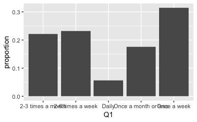

```r
Q1_table %>%
  ggplot(aes(x = Q1, y = proportion)) +
  geom_col()
```

Hmm, looks like we want to reorder the bars from the order in which the response options were shown.

Let’s relabel them.

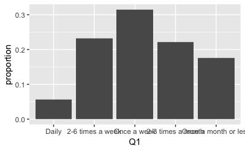

```r
Q1_table <-
  Q1_table %>%
  mutate(Q1 =
          fct_relevel(Q1,
                      "Daily",
                      "2-6 times a week",
                      "Once a week",
                      "2-3 times a month",
                      "Once a month or less")
  )
Q1_table %>%
  ggplot(aes(x = Q1, y = proportion)) +
  geom_col()
```

Now let’s get fancy

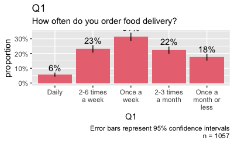

```r
Q1_table %>%
  ggplot(aes(x = Q1, y = proportion)) +
  geom_col(fill = "#EA7580") +
  geom_errorbar(
    aes(ymin = lower, ymax = upper),
    size = .5,
    width = 0,
    position = position_dodge(.7)
  ) +
  geom_text(aes(label = paste0(round(proportion*100), "%"), y = upper), vjust = -.3) +
  labs (
    title = "Q1",
    subtitle = "How often do you order food delivery?",
    caption = glue("Error bars represent 95% confidence intervals\nn = {Q1_table$total}")
  ) +
  scale_y_continuous(labels = scales::percent) +
  scale_x_discrete(labels = function(x) str_wrap(x, width = 10))
```

```r
Q2_table <- df_raw %>%
  group_by(Q2) %>%
  summarize(n = n()) %>%
  mutate(total = sum(n),
         proportion = (n/total),
         moe = calc_moe(proportion, total),
         lower = proportion - moe,
         upper = proportion + moe
  )
Q2_table
```

| Q2 | n | total | proportion | moe | lower | upper |
| --- | --- | --- | --- | --- | --- | --- |
| 0 | 185 | 1057 | 0.17502365 | 0.02290803 | 0.15211562 | 0.19793168 |
| 1 | 235 | 1057 | 0.22232734 | 0.02506764 | 0.19725970 | 0.24739498 |
| 2 | 332 | 1057 | 0.31409650 | 0.02798219 | 0.28611431 | 0.34207869 |
| 3 | 245 | 1057 | 0.23178808 | 0.02543927 | 0.20634881 | 0.25722735 |
| 4 or more | 60 | 1057 | 0.05676443 | 0.01394976 | 0.04281467 | 0.07071419 |

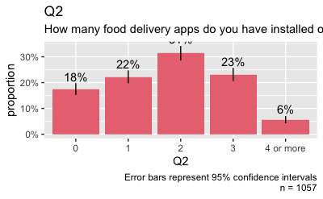

```r
Q2_table %>%
  ggplot(aes(x = Q2, y = proportion)) +
  geom_col(fill = "#EA7580") +
  geom_errorbar(
    aes(ymin = lower, ymax = upper),
    size = .5,
    width = 0,
    position = position_dodge(.7)
  ) +
  geom_text(aes(label = paste0(round(proportion*100), "%"), y = upper), vjust = -.3) +
  labs (
    title = "Q2",
    subtitle = "How many food delivery apps do you have installed on your phone?",
    caption = glue("Error bars represent 95% confidence intervals\nn = {Q2_table$total}")
  ) +
  scale_y_continuous(labels = scales::percent) +
  scale_x_discrete(labels = function(x) str_wrap(x, width = 10))
```

Multi-select questions require different code to analyze from the way it’s stored.

```r
Q3_table <- df_raw %>%
  select(starts_with("Q3")) %>%
  gather(question, response, na.rm=TRUE) %>%
  group_by(response) %>%
  summarize(n = n()) %>%
  mutate(total = sum(n),
         proportion = (n/total),
         moe = calc_moe(proportion, total),
         lower = proportion - moe,
         upper = proportion + moe
  )
Q3_table
```

| response | n | total | proportion | moe | lower | upper |
| --- | --- | --- | --- | --- | --- | --- |
| I don't have any groceries | 163 | 1548 | 0.10529716 | 0.015290382 | 0.09000678 | 0.12058754 |
| I don't have the time to cook | 702 | 1548 | 0.45348837 | 0.024800097 | 0.42868828 | 0.47828847 |
| I don't want to cook | 213 | 1548 | 0.13759690 | 0.017160505 | 0.12043639 | 0.15475740 |
| I want a specific meal or item | 114 | 1548 | 0.07364341 | 0.013011478 | 0.06063193 | 0.08665489 |
| I'm ordering for a group | 311 | 1548 | 0.20090439 | 0.019960190 | 0.18094420 | 0.22086458 |
| Other: | 45 | 1548 | 0.02906977 | 0.008369228 | 0.02070054 | 0.03743900 |

[figure not shown]

```r
Q3_table %>%
  ggplot(aes(x = response, y = proportion)) +
  geom_col(fill = "#EA7580") +
  geom_errorbar(
    aes(ymin = lower, ymax = upper),
    size = .5,
    width = 0,
    position = position_dodge(.7)
  ) +
  geom_text(aes(label = paste0(round(proportion*100), "%"), y = upper), vjust = -.3) +
  labs (
    title = "Q2",
    subtitle = "How many food delivery apps do you have installed on your phone?",
    caption = glue("Error bars represent 95% confidence intervals\nn = {Q2_table$total}")
  ) +
  scale_y_continuous(labels = scales::percent) +
  scale_x_discrete(labels = function(x) str_wrap(x, width = 10))
```

Let’s reorder this by frequency

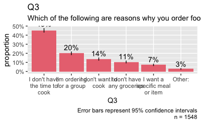

```r
Q3_table %>%
  ggplot(aes(x = reorder(response, -proportion), y = proportion)) +
  geom_col(fill = "#EA7580") +
  geom_errorbar(
    aes(ymin = lower, ymax = upper),
    size = .5,
    width = 0,
    position = position_dodge(.7)
  ) +
  geom_text(aes(label = paste0(round(proportion*100), "%"), y = upper), vjust = -.3) +
  labs (
    x = "Q3",
    title = "Q3",
    subtitle = "Which of the following are reasons why you order food delivery? Select all that apply.",
    caption = glue("Error bars represent 95% confidence intervals\nn = {Q3_table$total}")
  ) +
  scale_y_continuous(labels = scales::percent) +
  scale_x_discrete(labels = function(x) str_wrap(x, width = 15))
```

Let’s do Q4

```r
Q4_table <- df_raw %>%
  group_by(Q4) %>%
  summarize(n = n()) %>%
  mutate(total = sum(n),
         proportion = (n/total),
         moe = calc_moe(proportion, total),
         lower = proportion - moe,
         upper = proportion + moe
  )
Q4_table
```

| Q4 | n | total | proportion | moe | lower | upper |
| --- | --- | --- | --- | --- | --- | --- |
| American | 73 | 1057 | 0.069063387 | 0.015286307 | 0.0537770802 | 0.084349694 |
| Burgers | 236 | 1057 | 0.223273415 | 0.025105633 | 0.1981677826 | 0.248379048 |
| Chinese | 21 | 1057 | 0.019867550 | 0.008412656 | 0.0114548940 | 0.028280205 |
| Indian | 56 | 1057 | 0.052980132 | 0.013503758 | 0.0394763746 | 0.066483890 |
| Italian | 63 | 1057 | 0.059602649 | 0.014272730 | 0.0453299188 | 0.073875379 |
| Mexican | 122 | 1057 | 0.115421003 | 0.019263239 | 0.0961577639 | 0.134684242 |
| Other | 25 | 1057 | 0.023651845 | 0.009161223 | 0.0144906221 | 0.032813068 |
| Pizza | 306 | 1057 | 0.289498581 | 0.027341622 | 0.2621569591 | 0.316840203 |
| Sushi | 37 | 1057 | 0.035004730 | 0.011080122 | 0.0239246085 | 0.046084852 |
| Thai | 113 | 1057 | 0.106906339 | 0.018628111 | 0.0882782280 | 0.125534449 |

[output cut: 1 more lines]

```r
Q4_table <-
  df_raw %>%
  filter(!is.na(Q4)) %>%
  group_by(Q4) %>%
  summarize(n = n()) %>%
  mutate(total = sum(n),
         proportion = (n/total),
         moe = calc_moe(proportion, total),
         lower = proportion - moe,
         upper = proportion + moe
  )
Q4_table
```

| Q4 | n | total | proportion | moe | lower | upper |
| --- | --- | --- | --- | --- | --- | --- |
| American | 73 | 1052 | 0.06939163 | 0.015356252 | 0.05403538 | 0.08474789 |
| Burgers | 236 | 1052 | 0.22433460 | 0.025207719 | 0.19912688 | 0.24954232 |
| Chinese | 21 | 1052 | 0.01996198 | 0.008452233 | 0.01150974 | 0.02841421 |
| Indian | 56 | 1052 | 0.05323194 | 0.013566135 | 0.03966580 | 0.06679807 |
| Italian | 63 | 1052 | 0.05988593 | 0.014338406 | 0.04554753 | 0.07422434 |
| Mexican | 122 | 1052 | 0.11596958 | 0.019348792 | 0.09662079 | 0.13531837 |
| Other | 25 | 1052 | 0.02376426 | 0.009204235 | 0.01456002 | 0.03296849 |
| Pizza | 306 | 1052 | 0.29087452 | 0.027444959 | 0.26342957 | 0.31831948 |
| Sushi | 37 | 1052 | 0.03517110 | 0.011131824 | 0.02403928 | 0.04630293 |
| Thai | 113 | 1052 | 0.10741445 | 0.018711322 | 0.08870313 | 0.12612577 |

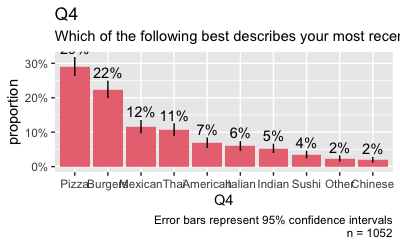

```r
Q4_table %>%
  ggplot(aes(x = reorder(Q4, -proportion), y = proportion)) +
  geom_col(fill = "#EA7580") +
  geom_errorbar(
    aes(ymin = lower, ymax = upper),
    size = .5,
    width = 0,
    position = position_dodge(.7)
  ) +
  geom_text(aes(label = paste0(round(proportion*100), "%"), y = upper), vjust = -.3) +
  labs (
    x = "Q4",
    title = "Q4",
    subtitle = "Which of the following best describes your most recent food delivery cuisine?",
    caption = glue("Error bars represent 95% confidence intervals\nn = {Q4_table$total}")
  ) +
  scale_y_continuous(labels = scales::percent) +
  scale_x_discrete(labels = function(x) str_wrap(x, width = 10))
```

```r
Q5_table <- df_raw %>%
  group_by(Q5) %>%
  summarize(n = n()) %>%
  mutate(total = sum(n),
         proportion = (n/total),
         moe = calc_moe(proportion, total),
         lower = proportion - moe,
         upper = proportion + moe
  ) %>%
  mutate(Q5 =
          fct_relevel(Q5,
                      "Extremely dissatisfied",
                      "Somewhat dissatisfied",
                      "Neither satisfied nor dissatisfied",
                      "Somewhat satisfied",
                      "Extremely satisfied")
  )
Q5_table
```

| Q5 | n | total | proportion | moe | lower | upper |
| --- | --- | --- | --- | --- | --- | --- |
| Extremely dissatisfied | 115 | 1057 | 0.1087985 | 0.01877232 | 0.09002617 | 0.1275708 |
| Extremely satisfied | 120 | 1057 | 0.1135289 | 0.01912511 | 0.09440374 | 0.1326540 |
| Neither satisfied nor dissatisfied | 263 | 1057 | 0.2488174 | 0.02606344 | 0.22275397 | 0.2748808 |
| Somewhat dissatisfied | 200 | 1057 | 0.1892148 | 0.02361288 | 0.16560188 | 0.2128276 |
| Somewhat satisfied | 359 | 1057 | 0.3396405 | 0.02855082 | 0.31108968 | 0.3681913 |

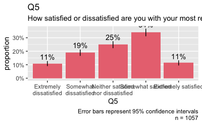

```r
Q5_table %>%
  ggplot(aes(x = Q5, y = proportion)) +
  geom_col(fill = "#EA7580") +
  geom_errorbar(
    aes(ymin = lower, ymax = upper),
    size = .5,
    width = 0,
    position = position_dodge(.7)
  ) +
  geom_text(aes(label = paste0(round(proportion*100), "%"), y = upper), vjust = -.3) +
  labs (
    title = "Q5",
    subtitle = "How satisfied or dissatisfied are you with your most recent food delivery order?",
    caption = glue("Error bars represent 95% confidence intervals\nn = {Q5_table$total}")
  ) +
  scale_y_continuous(labels = scales::percent) +
  scale_x_discrete(labels = function(x) str_wrap(x, width = 20))
```

Sometimes our stakeholders are only interested in the Top 2 Boxes. Let’s calculate them quickly.

```r
Q5_table_top2 <-
  df_raw %>%
  mutate(Q5 = case_when(
      Q5 %in% c("Extremely dissatisfied","Somewhat dissatisfied") ~ "Dissatisfied",
      Q5 %in% c("Extremely satisfied", "Somewhat satisfied") ~ "Satisfied",
      Q5 == "Neither satisfied nor dissatisfied" ~ "Neither"
    )) %>%
  group_by(Q5) %>%
  summarize(n = n()) %>%
  mutate(total = sum(n),
         proportion = (n/total),
         moe = calc_moe(proportion, total),
         lower = proportion - moe,
         upper = proportion + moe
)

Q5_table_top2
```

| Q5 | n | total | proportion | moe | lower | upper |
| --- | --- | --- | --- | --- | --- | --- |
| Dissatisfied | 315 | 1057 | 0.2980132 | 0.02757407 | 0.2704392 | 0.3255873 |
| Neither | 263 | 1057 | 0.2488174 | 0.02606344 | 0.2227540 | 0.2748808 |
| Satisfied | 479 | 1057 | 0.4531693 | 0.03001064 | 0.4231587 | 0.4831800 |

```r
NA
```

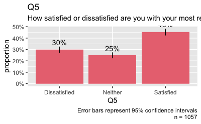

```r
Q5_table_top2 %>%
  ggplot(aes(x = Q5, y = proportion)) +
  geom_col(fill = "#EA7580") +
  geom_errorbar(
    aes(ymin = lower, ymax = upper),
    size = .5,
    width = 0,
    position = position_dodge(.7)
  ) +
  geom_text(aes(label = paste0(round(proportion*100), "%"), y = upper), vjust = -.3) +
  labs (
    title = "Q5",
    subtitle = "How satisfied or dissatisfied are you with your most recent food delivery order?",
    caption = glue("Error bars represent 95% confidence intervals\nn = {Q5_table$total}")
  ) +
  scale_y_continuous(labels = scales::percent) +
  scale_x_discrete(labels = function(x) str_wrap(x, width = 20))
```

If you remember that we used the `janitor` package earlier, you’ll see they have a function to quickly analyze top2 boxes. Try the function `top_levels()`

```r
top_levels(Q5_table$Q5)
```

```
                         Q5_table$Q5 n percent
      Extremely dissatisfied, Som... 2     0.4
 <<< Middle Group (1 categories) >>> 1     0.2
      Somewhat satisfied, Extreme... 2     0.4
```

```r
top_levels(Q5_table$Q5, n = 1)
```

```
                         Q5_table$Q5 n percent
              Extremely dissatisfied 1     0.2
 <<< Middle Group (3 categories) >>> 3     0.6
                 Extremely satisfied 1     0.2
```

```r
Q6_table <- df_raw %>%
  group_by(Q6) %>%
  summarize(n = n()) %>%
  mutate(total = sum(n),
         proportion = (n/total),
         moe = calc_moe(proportion, total),
         lower = proportion - moe,
         upper = proportion + moe
  )
Q6_table
```

| Q6 | n | total | proportion | moe | lower | upper |
| --- | --- | --- | --- | --- | --- | --- |
| Mobile app on smartphone | 679 | 1057 | 0.64238411 | 0.02889511 | 0.61348899 | 0.67127922 |
| Other: | 49 | 1057 | 0.04635762 | 0.01267570 | 0.03368192 | 0.05903331 |
| Phone call | 60 | 1057 | 0.05676443 | 0.01394976 | 0.04281467 | 0.07071419 |
| Web browser on desktop or laptop | 222 | 1057 | 0.21002838 | 0.02455632 | 0.18547206 | 0.23458470 |
| NA | 47 | 1057 | 0.04446547 | 0.01242663 | 0.03203884 | 0.05689209 |

```r
Q6_table <- df_raw %>%
  filter(!is.na(Q6)) %>% #remove null rows from this question
  group_by(Q6) %>%
  summarize(n = n()) %>%
  mutate(total = sum(n),
         proportion = (n/total),
         moe = calc_moe(proportion, total),
         lower = proportion - moe,
         upper = proportion + moe
  )
Q6_table
```

| Q6 | n | total | proportion | moe | lower | upper |
| --- | --- | --- | --- | --- | --- | --- |
| Mobile app on smartphone | 679 | 1010 | 0.67227723 | 0.02894829 | 0.64332894 | 0.70122552 |
| Other: | 49 | 1010 | 0.04851485 | 0.01325055 | 0.03526431 | 0.06176540 |
| Phone call | 60 | 1010 | 0.05940594 | 0.01457845 | 0.04482749 | 0.07398439 |
| Web browser on desktop or laptop | 222 | 1010 | 0.21980198 | 0.02553957 | 0.19426241 | 0.24534155 |

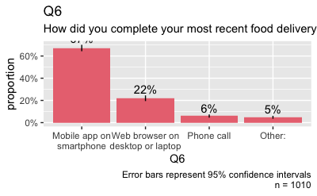

```r
Q6_table %>%
  ggplot(aes(x = reorder(Q6, -proportion), y = proportion)) +
  geom_col(fill = "#EA7580") +
  geom_errorbar(
    aes(ymin = lower, ymax = upper),
    size = .5,
    width = 0,
    position = position_dodge(.7)
  ) +
  geom_text(aes(label = paste0(round(proportion*100), "%"), y = upper), vjust = -.3) +
  labs (
    x = "Q6",
    title = "Q6",
    subtitle = "How did you complete your most recent food delivery order?",
    caption = glue("Error bars represent 95% confidence intervals\nn = {Q6_table$total}")
  ) +
  scale_y_continuous(labels = scales::percent) +
  scale_x_discrete(labels = function(x) str_wrap(x, width = 20))
```

```r
Q7_table <-
  df_raw %>%
  select(starts_with("Q7"), -ends_with("TEXT")) %>%
  gather(question,
         response) %>%
  group_by(question) %>%
  count(question,
        response) %>%
  mutate(
    total = sum(n),
    proportion = n/sum(n),
    moe = calc_moe(proportion, total),
         lower = proportion - moe,
         upper = proportion + moe) %>%
  filter(!is.na(response))
Q7_table
```

| question | response | n | total | proportion | moe | lower | upper |
| --- | --- | --- | --- | --- | --- | --- | --- |
| Q7_1 | Delivery time | 417 | 1057 | 0.3945128 | 0.02946467 | 0.36504810 | 0.4239774 |
| Q7_2 | Food temperature | 199 | 1057 | 0.1882687 | 0.02356751 | 0.16470117 | 0.2118362 |
| Q7_3 | Delivery price | 537 | 1057 | 0.5080416 | 0.03013925 | 0.47790238 | 0.5381809 |
| Q7_4 | Food packaging | 117 | 1057 | 0.1106906 | 0.01891474 | 0.09177589 | 0.1296054 |
| Q7_5 | Courier service | 143 | 1057 | 0.1352886 | 0.02061981 | 0.11466874 | 0.1559084 |
| Q7_6 | Other: | 115 | 1057 | 0.1087985 | 0.01877232 | 0.09002617 | 0.1275708 |

[figure not shown]

Let’s save this chart as a png so we can include it in a presentation.

```r
ggsave("Q7_plot.png")
```